# Case Study: Analysing Bike-share Data

K.Tarus

8/26/2021

This case study is completed as part of the Google Data Analytics Professional Certificate and it serves to highlight some of the skills gained from the program that can be applied in a position as a data analyst. I intend to use it to display skills such as data cleaning and manipulation, data analysis, visualisation and understanding business problems and how to leverage data to find solutions.

Data used has been made available by Motivate International Inc. under this [license](https://www.divvybikes.com/data-license-agreement). The data can be downloaded from [here](https://divvy-tripdata.s3.amazonaws.com/index.html).

### Business Task

Cyclistic is a bike-share company that has a both a subscription model and a pay-as-you-ride model. Its subscribers are called *members* and are more profitable than *casual* users of the service.

The objective of this analysis is to dig into the last 12 months of Cyclistic’s data to find out how members and casual riders differ in their use of Cyclistic services, and to find casual users that are the best candidates for conversion to members. The marketing team at Cyclistic is to leverage this knowledge to create a marketing campaign to that end.

#### Setting up the environment

We will use the *tidyverse* and *lubridate*

#### Importing the necessary data

The data used are contained in these files: Divvy_Trips_2019_Q2, Divvy_Trips_2019_Q3, Divvy_Trips_2019_Q4, Divvy_Trips_2020_Q1 from the source above.

### Data Cleaning and Manipulation

1. Renaming all columns from 2019 to be consistent with the column names below.

```
##  [1] "ride_id"            "rideable_type"      "started_at"
##  [4] "ended_at"           "start_station_name" "start_station_id"
##  [7] "end_station_name"   "end_station_id"     "start_lat"
## [10] "start_lng"          "end_lat"            "end_lng"
## [13] "member_casual"
```

Some differences in the data set:

- ride_id, q1_2019 is type *chr* while the rest are type *int*. Change all types to *chr*
- ridable_type, q1_2020 is inconsistent, contains type *chr* while the rest are type *int*. Change all types to *chr*
- q1_2020 does not contain column trip_duration. Omit column.
- Only q2, q3, q4 of 2019 contain columns for gender and birth year. Omit these columns.
- Only q1_2020 contains the columns: start_lat, start_lng, end_lat, end_lng. Omit these columns.

Fixing the inconsistencies listed above

```r
q4_2019 <-  mutate(q4_2019, ride_id = as.character(ride_id),
                   rideable_type = as.character(rideable_type))
q3_2019 <-  mutate(q3_2019, ride_id = as.character(ride_id),
                   rideable_type = as.character(rideable_type))
q2_2019 <-  mutate(q2_2019, ride_id = as.character(ride_id),
                   rideable_type = as.character(rideable_type))
```

2. Bring together the 4 data frames into one called ‘divvy_all_trips’.

```r
divvy_all_trips <- bind_rows(q2_2019, q3_2019, q4_2019, q1_2020)
View(divvy_all_trips)

divvy_all_trips <- divvy_all_trips %>%
  select(-c(X01...Rental.Details.Duration.In.Seconds.Uncapped, Member.Gender,
            X05...Member.Details.Member.Birthday.Year, gender, birthyear,
            start_lat, start_lng, end_lat, end_lng, tripduration, ride_id))

rm(q1_2020)
rm(q2_2019)
rm(q3_2019)
rm(q4_2019)
```

3.There are only 2 types of users but 4 labels in the member_casual column.

```r
divvy_all_trips <-  divvy_all_trips %>%
  mutate(member_casual = recode(member_casual
                                ,"Subscriber" = "member"
                                ,"Customer" = "casual"))
```

4. Create new columns for date, day, month, year and day of the week.

```r
divvy_all_trips$date <- as.Date(divvy_all_trips$started_at)
divvy_all_trips$month <- format(as.Date(divvy_all_trips$date), "%m")
divvy_all_trips$day <- format(as.Date(divvy_all_trips$date), "%d")
divvy_all_trips$year <- format(as.Date(divvy_all_trips$date), "%Y")
divvy_all_trips$day_of_week <- format(as.Date(divvy_all_trips$date), "%A")
```

5. Create a new column showing the duration of each trip.

```r
divvy_all_trips$trip_duration <- difftime(divvy_all_trips$ended_at,divvy_all_trips$started_at)

divvy_all_trips$trip_duration <- as.numeric(as.character(divvy_all_trips$trip_duration))

divvy_all_trips <- divvy_all_trips[!(divvy_all_trips$trip_duration<0),]
# 130 instances removed.

divvy_all_trips$ride_id[duplicated(divvy_all_trips$ride_id)] # Check for duplicated rows
# None found
```

6. Rides that begin from HQ QR indicate that the bike was taken out of the station for repair. These rows should be omitted.

```r
divvy_all_trips <- divvy_all_trips [!(divvy_all_trips$start_station_name == "HQ QR"),]
#3650 rows removed
divvy_all_trips <- divvy_all_trips [!(divvy_all_trips$end_station_name == "HQ QR"),]
#1 row removed
```

7. Putting the weekdays in chronological order.

```r
divvy_all_trips$day_of_week <- ordered(divvy_all_trips$day_of_week,
                                    levels=c("Monday", "Tuesday", "Wednesday",
                                             "Thursday", "Friday", "Saturday",
                                             "Sunday"))
```

### Analyzing the Data

#### Comparing the two user categories to find how they differ.

1. How many times do members and casual riders take non-stop round trips?

```
## # A tibble: 2 x 2
##   member_casual round_trips
##   <chr>               <int>
## 1 casual             108228
## 2 member              53451
```

```
## # A tibble: 2 x 2
##   member_casual all_trips
##   <chr>             <int>
## 1 casual           902182
## 2 member          2973859
```

We find that only about 2% of members take non-stop round trips, while about 12% of casual riders take round trips. This is true even though 76% of all rides recorded are by members.

2. Creating two data sets: trend_by_week and trend_by_month. The data sets summarize the number of trips and the length of the trips that users take by week and month.

```r
trend_by_week <- divvy_all_trips %>%
  group_by(member_casual, day_of_week) %>%                   #groups data by usertype and weekday
  summarise(number_of_rides = n(),                           #sums the number of rides
            average_duration = mean(trip_duration)) %>%      #calculates the average trip_duration
  arrange(member_casual, day_of_week)                        #arranges the data first by member_casual then by weekday

trend_by_month <- divvy_all_trips %>%
  group_by(member_casual, month) %>%
  summarise(number_of_rides = n(),
            average_duration = mean(trip_duration)) %>%
  arrange(month, member_casual)
```

The trend_by_week data set is visualized below to show any trends in the data.

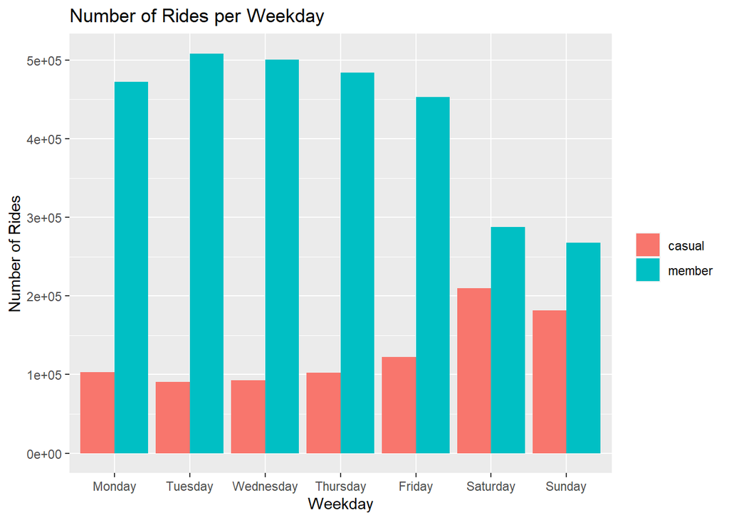

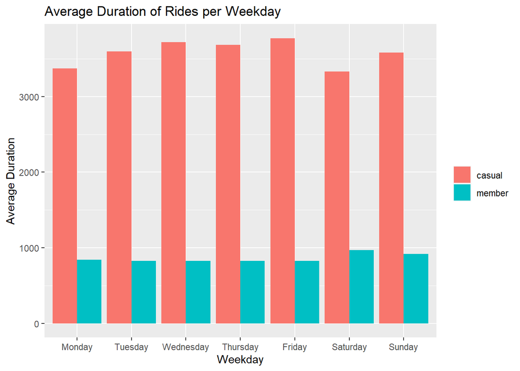

Members take shorter trips and ride more on weekdays. Casual riders take longer trips, and ride more on weekends. Add to this the fact that casual riders are about 6 times more likely that members to take a non-stop round trip and the data begins to paint a picture.

The data seem to indicate that most members use bikes to commute to work on weekdays.

To test this hypothesis, we need to ask what time of day do users start their trips most often? If this hypothesis is true, and assuming a 9 to 5 work day, we would expect two jumps in the number of trips members take, corresponding to when the work day starts and ends.

3. At what time of day do members and casual users start their trips?

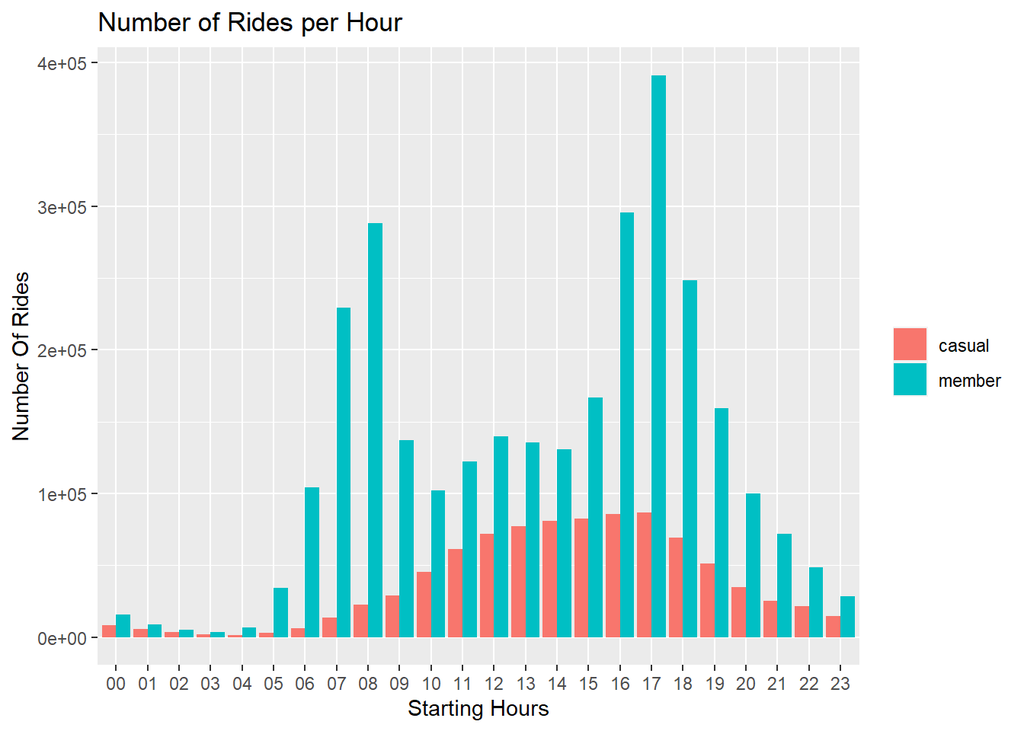

The graphs seems to confirm the hypothesis that most members ride to and from work.

This brings up another question; are there casual users whose pattern of bike use fits the pattern we’ve identified as being related to members?

4. Filtering for casual trips taken during the work week, and whose trip durations are close to the average trip duration of members may provide a clue. In this case we’ll limit the casual users trip duration to 1.5 times the average of members.

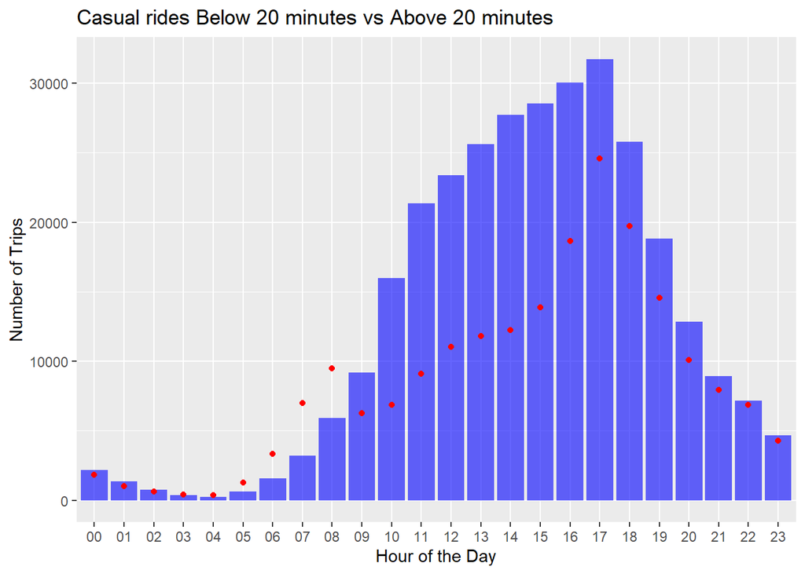

We see a noticeable bump in the number of trips that start at 8 for trips that are shorter than 20 minutes(red dots). This bump goes away for trips longer than 20 minutes(blue bar). This hints that we might be able to identify casual riders that are a good fit for conversion to members.

It is also interesting to note the huge rise in trip numbers that start around 5. Might more casual riders be taking trips back home from work than those who take trips to work?

More data, which is unavailable, is needed to answer the questions brought up by this preliminary analysis.

### Key findings

1. Key target for conversion are casual riders whose trips begin at 8am and 5pm on weekdays.
2. Most members use the Cyclistic service to commute to and from work on weekdays.
3. More data, specifically user ID that ties a trip to a specific user is needed for further analysis. This data might help clarify whether the massive influx of trips by casual riders at 5pm corresponds to people commuting home, and thus give us another avenue for creating marketing campaigns for conversion.